# **Can we use Machine Learning Classifications to Reliably Classify Spotify Songs by Type of Popularity?**

**Sidney Howard-Clinton**

Spotify is perhaps the most widely recognized streaming service available. It’s wide catalogue of songs and ease of accessibility make it the first choice for music enthusiast. One of the more innovative features of Spotify is its abilities to allow users to create and share their own public playlists with the community. However, Spotify additionally creates and curates their own playlists to share with the community. Two of these playlists are Spotify’s “Viral Top 50” and “Top 200”. As you might have guessed the “Top 200” playlist is an amalgamation of the top 200 most streamed songs at any given moment. The “Viral Top 50” however is a bit more ambiguous. According to a Spotify employee’s response in a post on the Spotify forums, “the Viral 50 chart has been created to measure the success of music in terms of user sharing combining analytics on blogs, social media etc”.

Additionally, Spotify analyzes songs to discern their “features” and using their own libraries, Spotify allows developers to access these songs features using their "Spotipy" python library. These features include “acousticness”, “danceability”, tempo, energy etc. More will be discussed about these features later. For this reason, I thought it would be fascinating to use these audio features Spotify has collected and use machine learning classification algorithms to attempt to classify songs as belonging to either the “Viral 50” or “Top 200” playlist. Is it even possible to discern a difference between “viral” songs and top songs? What classification algorithm would be optimal? Our human intuition would have us believe that the most viral songs would be indistinguishable from the top songs. If our classification is at all successful, it begs the question to what extent can a songs virality and popularity be quantified based on its auditory characteristics.

```python
pip install spotipy
```

# Data Collection and Processing

The playlist data we'll be using for this analysis was collected by user “Dhruvil Dave” on [Kaggle](https://www.kaggle.com/datasets/dhruvildave/spotify-charts). Spotify publishes the “Top 200” and “Viral 50” charts every 2-3 days. This user has created a CSV file with the entire collection of charts dating back from January 1, 2017. The CSV contains around 26 million entries and has the song’s name, rank, its playlist (either “Viral 50 or “Top 200”) and its respective URL (which we will need to access the audio features) along with a few other data points which won’t be needed for this particular analysis.

```python
from google.colab import drive
import pandas as pd
import spotipy
import pandas as pd
from spotipy.oauth2 import SpotifyClientCredentials
import numpy as np
%matplotlib inline
import matplotlib.pyplot as plt
import seaborn as sns
from sklearn.tree import DecisionTreeClassifier
from sklearn.ensemble import RandomForestClassifier
from sklearn.neighbors import KNeighborsClassifier
from sklearn.metrics import classification_report
from sklearn.linear_model import LogisticRegression
import sklearn.model_selection as ms
import sklearn.metrics as met
from sklearn.neighbors import KNeighborsClassifier
drive.mount('/content/gdrive')
%cd /content/gdrive/MyDrive

#import data from csv file
spotifySongs = pd.read_csv("charts.csv")
```

```
/content/gdrive/MyDrive
```

Because songs that make this playlist will often remain on them several days (or weeks), I thought it would be needed to filter out these songs to not bias our analysis towards a few biggest hits. Our dataframe has a column named “trend” that stores a songs position movement within the playlist. Songs can either move up, down or be newly entered into the playlist. For this analysis, I will only use newly entered songs to remove the possibility of a few biggest hits having a disproportionate impact on our data.

```python
print("Number of total songs:", len(spotifySongs.index))
newEntry_df = spotifySongs[spotifySongs["trend"] == "NEW_ENTRY"]
print("Number of New_Entry songs:", len(newEntry_df.index))
```

```
Number of total songs: 26173514
Number of New_Entry songs: 1853640
```

We now have our dataframe of only newly entered songs. From this we will separate our data into two different sets, a set contacting “Viral 50” songs and the other containing “Top 200” songs.

```python
#Store viral50 and top200 into different data frames
top200_df = newEntry_df[newEntry_df["chart"] == "top200"]
print("Number of top200 songs", len(top200_df.index))

viral50_df = newEntry_df[newEntry_df["chart"] == "viral50"]
print("Number of viral50 songs", len(viral50_df.index))
```

```
Number of top200 songs 1181542
Number of viral50 songs 672098
```

```python
#Get 50000 random samples from viral50 and top200 and store them in new dataframe
top200_sample = top200_df.sample(n=50000)
viral50_sample = viral50_df.sample(n=50000)

#Append dataframe together
top100000 = top200_sample.append(viral50_sample)
#reset index
top100000 = top100000.reset_index(drop=True)
top100000.head()
```

|  | title | rank | date | artist | url | region | chart | trend | streams |
| --- | --- | --- | --- | --- | --- | --- | --- | --- | --- |
| 0 | Wait | 190 | 2017-10-18 | Martin Jensen, Loote | https://open.spotify.com/track/3V9DfRoS7JfSkuT... | Malaysia | top200 | NEW_ENTRY | 3730.0 |
| 1 | Jocelyn Flores | 169 | 2019-12-26 | XXXTENTACION | https://open.spotify.com/track/7m9OqQk4RVRkw9J... | Finland | top200 | NEW_ENTRY | 5925.0 |
| 2 | Come Closer (feat. Drake) | 150 | 2017-06-30 | WizKid | https://open.spotify.com/track/2f9LSU0aBW04w6K... | United Kingdom | top200 | NEW_ENTRY | 51171.0 |
| 3 | Friends (with BloodPop®) | 126 | 2017-08-17 | Justin Bieber | https://open.spotify.com/track/7iNIg7XDEaYECfW... | Honduras | top200 | NEW_ENTRY | 1001.0 |
| 4 | Sweet Child O' Mine | 179 | 2018-12-17 | Guns N' Roses | https://open.spotify.com/track/7o2CTH4ctstm8TN... | Mexico | top200 | NEW_ENTRY | 50757.0 |

Now that we have our data frame of 100,000 songs, it’s time to use our Spotipy library to get the auditory features of the songs.

```python
#Required IDs for web requests
cid = "58ff3ad8fc2446669ee16d1a75185ba8"
secret = "85504b94651641a7ad56602bfac5eab9"
client_credentials_managerMan = SpotifyClientCredentials(client_id=cid, client_secret=secret)
#Create new Spotipy object using our credentials
sp = spotipy.Spotify(client_credentials_manager = client_credentials_managerMan)

#Simply do a sample request to figure out the structure of our dataframe
element = top100000.head(1)["url"]
firstTrack = sp.audio_features(element)
#sp.audio_features returns an array of 1 element
print(firstTrack[0].keys())
#Now that we now the structure, create a new dataframe that we fill next
df = pd.DataFrame(columns = firstTrack[0].keys())
df
```

```
dict_keys(['danceability', 'energy', 'key', 'loudness', 'mode', 'speechiness', 'acousticness', 'instrumentalness', 'liveness', 'valence', 'tempo', 'type', 'id', 'uri', 'track_href', 'analysis_url', 'duration_ms', 'time_signature'])
```

|  | danceability | energy | key | loudness | mode | speechiness | acousticness | instrumentalness | liveness | valence | tempo | type | id | uri | track_href | analysis_url | duration_ms | time_signature |
| --- | --- | --- | --- | --- | --- | --- | --- | --- | --- | --- | --- | --- | --- | --- | --- | --- | --- | --- |

The following block is where we will get the auditory attributes of all the songs in our dataframe. Using the songs URL, we make a web request to get songs attributes from Spotify and then concatenate those columns to our main dataframe. For 100,000 songs this process took around 2 and a half hours. Because of this I chose to export the data frame to CSV so that I could rerun my code without having to repeating scrape all this data. If a new set of data is desired, the code can simply be rerun but be warned it will take lots of time to collect the attributes.

```python
i = 0
for index,element in top100000.iterrows():
    url = element["url"]
    rank = element["rank"]
    region = element["region"]
    chart = element["chart"]
    trend = element["trend"]
    streams = element["streams"]
    artist =  element["artist"]
    title =  element["title"]
    date =  element["date"]
    mytrack = sp.audio_features(url)[0]
    df2 = pd.DataFrame(mytrack, index=[0])

    #pd.concat([element, df2])
    #df.concat(e
    df2["rank"] = rank
    df2["artist"] = artist
    df2["title"] = title
    df2["date"] = date
    df2["chart"] = chart
    df2["trend"] = trend
    df2["streams"] = streams
    df2["region"] = region
    df = df.append(df2, ignore_index = True)
    print(i)
    i += 1
```

```python
df.head()
```

[output not shown]

5 rows × 26 columns

# Preliminary Data Analysis

Now that we have our song attributes it would be interesting if we can find some trends between a songs attributes and its classification (Top 200 or Viral 50). What are the general differences between top 200 songs and viral 50 songs?

We will start by finding the mean of each attribute between the two sets. Each attribute will be graphed and the attribute definitions will be explained.

```python
temp = df[df.chart == 'top200']
print("Top 200 average danceability = ", temp['danceability'].mean())
print("Top 200 average energy = ", temp['energy'].mean())
print("Top 200 average key = ", temp['key'].mean())
print("Top 200 average loudness = ", temp['loudness'].mean())
print("Top 200 average mode = ", temp['mode'].mean())
print("Top 200 average speechiness = ", temp['speechiness'].mean())
print("Top 200 average acousticness = ", temp['acousticness'].mean())
print("Top 200 average instrumentalness = ", temp['instrumentalness'].mean())
print("Top 200 average liveness = ", temp['liveness'].mean())
print("Top 200 average valence = ", temp['valence'].mean())
print("Top 200 average tempo = ", temp['tempo'].mean())
print("Top 200 average duration = ", temp['duration_ms'].mean())
print("Top 200 average time signature = ", temp['time_signature'].mean())
```

```
Top 200 average danceability =  0.6669118049443795
Top 200 average energy =  0.6359373943915474
Top 200 average key =  5.326306104488359
Top 200 average loudness =  -6.543201296103805
Top 200 average mode =  0.5959876790143211
Top 200 average speechiness =  0.1037427814225151
Top 200 average acousticness =  0.2663115525650012
Top 200 average instrumentalness =  0.013749337678614344
Top 200 average liveness =  0.17168871909752675
Top 200 average valence =  0.5131112430994526
Top 200 average tempo =  120.87465651251976
Top 200 average duration =  211409.10312825025
Top 200 average time signature =  3.9577766221297703
```

```python
temp = df[df.chart == 'viral50']
print("Viral 50 average danceability = ", temp['danceability'].mean())
print("Viral 50 average energy = ", temp['energy'].mean())
print("Viral 50 average key = ", temp['key'].mean())
print("Viral 50 average loudness = ", temp['loudness'].mean())
print("Viral 50 average mode = ", temp['mode'].mean())
print("Viral 50 average speechiness = ", temp['speechiness'].mean())
print("Viral 50 average acousticness = ", temp['acousticness'].mean())
print("Viral 50 average instrumentalness = ", temp['instrumentalness'].mean())
print("Viral 50 average liveness = ", temp['liveness'].mean())
print("Viral 50 average valence = ", temp['valence'].mean())
print("Viral 50 average tempo = ", temp['tempo'].mean())
print("Viral 50 average duration = ", temp['duration_ms'].mean())
print("Viral 50 average time signature = ", temp['time_signature'].mean())
```

```
Viral 50 average danceability =  0.6685397947958793
Viral 50 average energy =  0.6405003721674497
Viral 50 average key =  5.299365987319747
Viral 50 average loudness =  -6.776738154763107
Viral 50 average mode =  0.5738714774295486
Viral 50 average speechiness =  0.112738438768774
Viral 50 average acousticness =  0.25581176640292413
Viral 50 average instrumentalness =  0.042224493592272316
Viral 50 average liveness =  0.17602807236144483
Viral 50 average valence =  0.5000688383767685
Viral 50 average tempo =  121.21223918478265
Viral 50 average duration =  211043.7322146443
Viral 50 average time signature =  3.959659193183864
```

After collecting the means, we will create histograms to compare the distrubtion of the attributes within the two sets. Seaborn's distplot library will automatically calculate the interval ranges.

[figure not shown]

```python
import warnings
warnings.filterwarnings('ignore')

plt.figure(1, figsize=(50, 40),)
hfont = {'fontname':'Proxima Nova'}

plt.subplot(771)
temp = df[df.chart == 'top200']
sns.distplot(temp['danceability'], kde=True, label = 'Top 200')
temp = df[df.chart == 'viral50']
sns.distplot(temp['danceability'], kde=True, label = 'Viral 50')
plt.text(0.10, 1.5, r'$Top\ 200 \ mu=\ 0.667$', fontsize=22)
plt.text(0.10, 1, r'$Viral\ 50 \ mu=\ 0.669$', fontsize=22)
plt.xlabel('Danceability ', fontsize=15, **hfont)
plt.legend(prop={'size': 12})
plt.grid(True)

plt.subplot(772)
temp = df[df.chart == 'top200']
sns.distplot(temp['energy'], kde=True, label = 'Top 200')
temp = df[df.chart == 'viral50']
sns.distplot(temp['energy'], kde=True, label = 'Viral 50')
plt.text(0.10, 1.5, r'$Top\ 200 \ mu=\ 0.636$', fontsize=22)
plt.text(0.10, 1, r'$Viral\ 50 \ mu=\ 0.641$', fontsize=22)
plt.xlabel('Energy', fontsize=15, **hfont)
plt.legend(prop={'size': 12})
plt.grid(True)

plt.subplot(773)
temp = df[df.chart == 'top200']
sns.distplot(temp['key'], kde=True, label = 'Top 200')
temp = df[df.chart == 'viral50']
sns.distplot(temp['key'], kde=True, label = 'Viral 50')
plt.text(2, 0.25, r'$Top\ 200 \ mu=\ 5$', fontsize=22)
plt.text(2, 0.15, r'$Viral\ 50 \ mu=\ 5$', fontsize=22)
plt.xlabel('Key', fontsize=15, **hfont)
plt.legend(prop={'size': 12})
plt.grid(True)

plt.subplot(774)
temp = df[df.chart == 'top200']
sns.distplot(temp['loudness'], kde=True, label = 'Top 200')
temp = df[df.chart == 'viral50']
sns.distplot(temp['loudness'], kde=True, label = 'Viral 50')
plt.text(-45, 0.075, r'$Top\ 200 \ mu=\ -6.543$', fontsize=22)
plt.text(-45, 0.055, r'$Viral\ 50 \ mu=\ -6.777$', fontsize=22)
plt.xlabel('Loudness', fontsize=15, **hfont)
plt.legend(prop={'size': 12})
plt.grid(True)

plt.subplot(775)
temp = df[df.chart == 'top200']
sns.distplot(temp['mode'], kde=True, label = 'Top 200')
temp = df[df.chart == 'viral50']
sns.distplot(temp['mode'], kde=True, label = 'Viral 50')
plt.text(0.10, 4, r'$Top\ 200 \ mu=\ 1$', fontsize=22)
plt.text(0.10, 2, r'$Viral\ 50 \ mu=\ 1$', fontsize=22)
plt.xlabel('Mode', fontsize=15, **hfont)
plt.legend(prop={'size': 12})
plt.grid(True)

plt.subplot(776)
temp = df[df.chart == 'top200']
sns.distplot(temp['speechiness'], kde=True, label = 'Top 200')
temp = df[df.chart == 'viral50']
sns.distplot(temp['speechiness'], kde=True, label = 'Viral 50')
plt.text(0.10, 4, r'$Top\ 200 \ mu=\ 0.104$', fontsize=22)
plt.text(0.10, 2, r'$Viral\ 50 \ mu=\ 0.113$', fontsize=22)
plt.xlabel('Speechiness', fontsize=15, **hfont)
plt.legend(prop={'size': 12})
plt.grid(True)

plt.subplot(777)
temp = df[df.chart == 'top200']
sns.distplot(temp['acousticness'], kde=True, label = 'Top 200')
temp = df[df.chart == 'viral50']
sns.distplot(temp['acousticness'], kde=True, label = 'Viral 50')
plt.text(0.10, 4, r'$Top\ 200 \ mu=\ 0.266$', fontsize=22)
plt.text(0.10, 2, r'$Viral\ 50 \ mu=\ 0.256$', fontsize=22)
plt.xlabel('Acousticness', fontsize=15, **hfont)
plt.legend(prop={'size': 12})
plt.grid(True)

plt.subplot(778)
temp = df[df.chart == 'top200']
sns.distplot(temp['instrumentalness'], kde=True, label = 'Top 200')
temp = df[df.chart == 'viral50']
sns.distplot(temp['instrumentalness'], kde=True, label = 'Viral 50')
plt.text(0.10, 20, r'$Top\ 200 \ mu=\ 0.0137$', fontsize=22)
plt.text(0.10, 10, r'$Viral\ 50 \ mu=\ 0.0422$', fontsize=22)
plt.xlabel('Instrumentalness', fontsize=15, **hfont)
plt.legend(prop={'size': 12})
plt.grid(True)

plt.subplot(779)
temp = df[df.chart == 'top200']
sns.distplot(temp['liveness'], kde=True, label = 'Top 200')
temp = df[df.chart == 'viral50']
sns.distplot(temp['liveness'], kde=True, label = 'Viral 50')
plt.text(0.10, 4, r'$Top\ 200 \ mu=\ 0.177$', fontsize=22)
plt.text(0.10, 3, r'$Viral\ 50 \ mu=\ 0.176$', fontsize=22)
plt.xlabel('Liveness', fontsize=15, **hfont)
plt.legend(prop={'size': 12})
plt.grid(True)

plt.subplot(7,7,10)
temp = df[df.chart == 'top200']
sns.distplot(temp['valence'], kde=True, label = 'Top 200')
temp = df[df.chart == 'viral50']
sns.distplot(temp['valence'], kde=True, label = 'Viral 50')
plt.text(0.2, 0.6, r'$Top\ 200 \ mu=\ 0.513$', fontsize=22)
plt.text(0.2, 0.4, r'$Viral\ 50 \ mu=\ 0.500$', fontsize=22)
plt.xlabel('Valence', fontsize=15, **hfont)
plt.legend(prop={'size': 12})
plt.grid(True)

plt.subplot(7,7,11)
temp = df[df.chart == 'top200']
sns.distplot(temp['tempo'], kde=True, label = 'Top 200')
temp = df[df.chart == 'viral50']
sns.distplot(temp['tempo'], kde=True, label = 'Viral 50')
plt.text(50, 0.0075, r'$Top\ 200 \ mu=\ 120.875$', fontsize=22)
plt.text(50, 0.0050, r'$Viral\ 50 \ mu=\ 121.212$', fontsize=22)
plt.xlabel('Tempo', fontsize=15, **hfont)
plt.legend(prop={'size': 12})
plt.grid(True)

plt.subplot(7,7,12)
temp = df[df.chart == 'top200']
sns.distplot(temp['duration_ms'], kde=True, label = 'Top 200')
temp = df[df.chart == 'viral50']
sns.distplot(temp['duration_ms'], kde=True, label = 'Viral 50')
plt.text(1, 0.000004, r'$Top\ 200 \ mu=\ 211409$', fontsize=22)
plt.text(1, 0.000002, r'$Viral\ 50 \ mu=\ 211044$', fontsize=22)
plt.xlabel('Duration', fontsize=15, **hfont)
plt.legend(prop={'size': 12})
plt.grid(True)

plt.subplot(7,7,13)
temp = df[df.chart == 'top200']
sns.distplot(temp['time_signature'], kde=True, label = 'Top 200')
temp = df[df.chart == 'viral50']
sns.distplot(temp['time_signature'], kde=True, label = 'Viral 50')
plt.text(1, 4, r'$Top\ 200 \ mu=\ 4$', fontsize=22)
plt.text(1, 2, r'$Viral\ 50 \ mu=\ 4$', fontsize=22)
plt.xlabel('Time Signature', fontsize=15, **hfont)
plt.legend(prop={'size': 12})
plt.grid(True)
```

“Danceability” is defined by Spotify as: “how suitable a track is for dancing based on a combination of musical elements including tempo, rhythm stability, beat strength, and overall regularity. A value of 0.0 is least danceable and 1.0 is most danceable.”

The two sets have a very similar average “danceability” value.

“Energy” is defined by Spotify as: “a measure from 0.0 to 1.0 and represents a perceptual measure of intensity and activity. Typically, energetic tracks feel fast, loud, and noisy. For example, death metal has high energy, while a Bach prelude scores low on the scale. Perceptual features contributing to this attribute include dynamic range, perceived loudness, timbre, onset rate, and general entropy.”

The two sets have a very similar average “energy” value.

“Key” is defined by Spotify as: “The key the track is in. Integers map to pitches using standard Pitch Class notation. E.g. 0 = C, 1 = C♯/D♭, 2 = D, and so on. If no key was detected, the value is -1.”

The average key is the same between both sets.

“Loudness” is defined by Spotify as: “The overall loudness of a track in decibels (dB). Loudness values are averaged across the entire track and are useful for comparing relative loudness of tracks. Loudness is the quality of a sound that is the primary psychological correlate of physical strength (amplitude). Values typically range between -60 and 0 db.”

The two sets have a similar average “loudness” value.

“Mode” is defined by Spotify as: “the modality (major or minor) of a track, the type of scale from which its melodic content is derived. Major is represented by 1 and minor is 0.”

The average mode is the same between both sets.

“Speechiness” is defined by Spotify as: “the presence of spoken words in a track. The more exclusively speech-like the recording (e.g. talk show, audio book, poetry), the closer to 1.0 the attribute value. Values above 0.66 describe tracks that are probably made entirely of spoken words. Values between 0.33 and 0.66 describe tracks that may contain both music and speech, either in sections or layered, including such cases as rap music. Values below 0.33 most likely represent music and other non-speech-like tracks.”

The two sets have a similar average “speechiness” value.

“Acousticness” is defined by Spotify as: “A confidence measure from 0.0 to 1.0 of whether the track is acoustic. 1.0 represents high confidence the track is acoustic.”

The two sets have a similar average “acousticness” value.

“Instrumentalness” is defined as Spotify as: “whether a track contains no vocals. "Ooh" and "aah" sounds are treated as instrumental in this context. Rap or spoken word tracks are clearly "vocal". The closer the instrumentalness value is to 1.0, the greater likelihood the track contains no vocal content. Values above 0.5 are intended to represent instrumental tracks, but confidence is higher as the value approaches 1.0.”

It seems the viral 50 songs are on average 3 times more instrumental than top 200 songs! This may be a key feature in classify the songs later.

“Liveness” is defined by Spotify as: “the presence of an audience in the recording. Higher liveness values represent an increased probability that the track was performed live. A value above 0.8 provides strong likelihood that the track is live.”

The two sets have a similar average “liveness” value.

“Valence” is defined by Spotify as: “A measure from 0.0 to 1.0 describing the musical positiveness conveyed by a track. Tracks with high valence sound more positive (e.g. happy, cheerful, euphoric), while tracks with low valence sound more negative (e.g. sad, depressed, angry).”

The two sets have a similar average “valence” value.

“Tempo” is defined by Spotify as: “The overall estimated tempo of a track in beats per minute (BPM). In musical terminology, tempo is the speed or pace of a given piece and derives directly from the average beat duration.”

The two sets have a similar average “tempo” value.

Finally, “time Signature” is defined by Spotify as “An estimated time signature. The time signature (meter) is a notational convention to specify how many beats are in each bar (or measure). The time signature ranges from 3 to 7 indicating time signatures of "3/4", to "7/4".

The average time signature of both sets is a standard 4/4 time signature.

Upon observation, there seems to be a predictable extreme similarity between the attributes of viral 50 songs and top 200 songs. The only standout feature being “instrumentalness”. The viral 50 songs are on average 3 times more instrumental than top 200 songs. Perhaps this will be the key factor in our machine learning models in determining classification.

# Classifying Songs Based on Attributes: A Performance Comparison of Decision Trees, K-nearest Neighbors, Logistic Regression and Random Forests

It's time to build our classifers. We will be using sklearn for all the machine learning in our analysis.

```python
#Clean up columns
df = df.drop(columns=['region','artist', 'title', 'analysis_url', 'track_href', 'id', 'uri', 'date', 'trend','streams', 'type', 'rank'])
df.head()
```

|  | danceability | energy | key | loudness | mode | speechiness | acousticness | instrumentalness | liveness | valence | tempo | duration_ms | time_signature | chart |
| --- | --- | --- | --- | --- | --- | --- | --- | --- | --- | --- | --- | --- | --- | --- |
| 0 | 0.715 | 0.862 | 10.0 | -2.718 | 0.0 | 0.0444 | 0.0113 | 0.000000 | 0.1080 | 0.668 | 137.930 | 197800.0 | 4.0 | top200 |
| 1 | 0.276 | 0.308 | 5.0 | -10.459 | 1.0 | 0.0392 | 0.4500 | 0.000006 | 0.6100 | 0.381 | 92.252 | 82813.0 | 4.0 | top200 |
| 2 | 0.509 | 0.637 | 4.0 | -4.830 | 0.0 | 0.0471 | 0.0717 | 0.000011 | 0.0789 | 0.378 | 172.006 | 224000.0 | 3.0 | top200 |
| 3 | 0.622 | 0.796 | 0.0 | -2.999 | 0.0 | 0.1720 | 0.6670 | 0.000000 | 0.1060 | 0.620 | 197.705 | 169813.0 | 4.0 | top200 |
| 4 | 0.838 | 0.944 | 11.0 | -4.163 | 0.0 | 0.2460 | 0.1250 | 0.000000 | 0.0768 | 0.866 | 144.014 | 248420.0 | 4.0 | top200 |

Some rows may contain values not compatible with sklearn. Due to this we are using pandas fillna() method to automatically propagate non-null values forward or backward. I believe this method of imputation will have the least amount of impact on our models, especially as the graphs before have shown the remarkably similarity between viral 50 and top 200 songs.

```python
#change chart column values to integers to make categorial object from it
for i in df.index:
    if df.at[i, 'chart'] == 'top200':
        df.at[i, 'chart'] = 1
    else:
        df.at[i, 'chart'] = 0
#sklearn has trouble with inf
df.isnull().any()
#impute null values
df= df.fillna(method='ffill')
```

```python
#Convert column into numpy array
array = df['chart'].to_numpy()
#Create categorial object for dependent variable
dep = pd.Categorical.from_codes(array, ['viral50', 'top200'])
ind = df.drop(columns=['chart'])
```

```python
#represent categories as ints
dep_split = pd.get_dummies(dep)
dep_split
```

|  | viral50 | top200 |
| --- | --- | --- |
| 0 | 0 | 1 |
| 1 | 0 | 1 |
| 2 | 0 | 1 |
| 3 | 0 | 1 |
| 4 | 0 | 1 |
| ... | ... | ... |
| 99995 | 1 | 0 |
| 99996 | 1 | 0 |
| 99997 | 1 | 0 |
| 99998 | 1 | 0 |
| 99999 | 1 | 0 |

100000 rows × 2 columns

```python
#Randomly split data into test and training sets
ind_train, ind_test, dep_train, dep_test = ms.train_test_split(ind, dep)
print(ind_train.size, ind_test.size)
```

```
975000 325000
```

```
              precision    recall  f1-score   support

      top200       0.65      0.72      0.68     12468
     viral50       0.69      0.62      0.65     12532

    accuracy                           0.67     25000
   macro avg       0.67      0.67      0.67     25000
weighted avg       0.67      0.67      0.67     25000
```

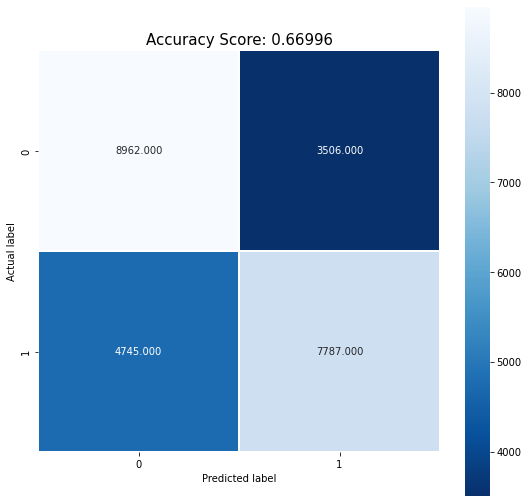

```python
dt = DecisionTreeClassifier()
dt.fit(ind_train, dep_train)
predicted = dt.predict(ind_test)
print(classification_report(dep_test, predicted))
#Score method returns average accuracy of model

score = dt.score(ind_test, dep_test)
cm = met.confusion_matrix(dep_test, predicted)
plt.figure(figsize=(9,9))
sns.heatmap(cm, annot=True, fmt=".3f", linewidths=.5, square = True, cmap = 'Blues_r');
plt.ylabel('Actual label');
plt.xlabel('Predicted label');
all_sample_title = 'Accuracy Score: {0}'.format(score)
plt.title(all_sample_title, size = 15);
```

A decision tree is a supervised learning algorithm that specializes in classification problems. It is similar to how a flow chart works where data points are separated into two smaller categories at a time. Consequently, I expect this to be great classification algorithm for my problem. From our output, we can observe the model has an accuracy of 0.67 overall and an f1-score of 0.68 for the top 200 set and 0.65 for the viral 50 set. F1-score is calculating using the precision and recall scores of the model. Precision is calculated using the formula: precision = true positive / (true positive + false positive). Recall is calculated using the formula: recall = true positive/ (true positive + false negative). A f1-score of 1 indicates a perfect model. Accuracy tells us the overall performance of the model. For each classification algorithm I generate a confusion matrix to clearly visualize the performance of the algorithm.

It seems decision trees performed fairly well with an accuracy of 0.67. This means that the decision tree was right in classifying songs 67% of the time.

```
              precision    recall  f1-score   support

      top200       0.70      0.66      0.68     12468
     viral50       0.68      0.72      0.70     12532

    accuracy                           0.69     25000
   macro avg       0.69      0.69      0.69     25000
weighted avg       0.69      0.69      0.69     25000
```

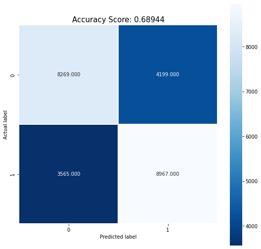

```python
rf = RandomForestClassifier()
rf.fit(ind_train, dep_train)
predicted = rf.predict(ind_test)
print(classification_report(dep_test, predicted))

score = rf.score(ind_test, dep_test)
cm = met.confusion_matrix(dep_test, predicted)
plt.figure(figsize=(9,9))
sns.heatmap(cm, annot=True, fmt=".3f", linewidths=.5, square = True, cmap = 'Blues_r');
plt.ylabel('Actual label');
plt.xlabel('Predicted label');
all_sample_title = 'Accuracy Score: {0}'.format(score)
plt.title(all_sample_title, size = 15);
```

Random forests are similar to decision trees but use a multitude of randomly created decision trees for classification. This makes it ideal for large data sets. Here we can observe that it performed slightly better than our decision tree algorithm. With an accuracy of 0.69, it was correct around 2% more than our decision tree.

```
              precision    recall  f1-score   support

      top200       0.64      0.65      0.65     12468
     viral50       0.65      0.64      0.64     12532

    accuracy                           0.65     25000
   macro avg       0.65      0.65      0.65     25000
weighted avg       0.65      0.65      0.65     25000
```

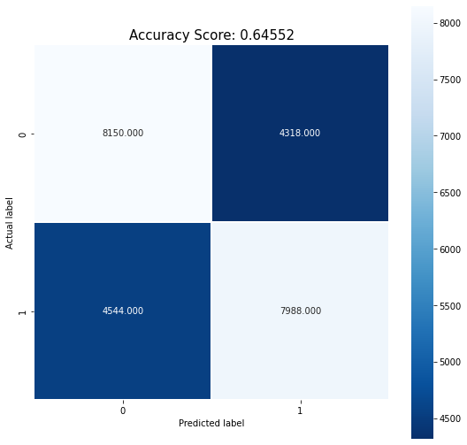

```python
model = KNeighborsClassifier(n_neighbors=1)
model.fit(ind_train,dep_train)
predicted = model.predict(ind_test)
print(classification_report(dep_test, predicted))

score = model.score(ind_test, dep_test)
cm = met.confusion_matrix(dep_test, predicted)
plt.figure(figsize=(9,9))
sns.heatmap(cm, annot=True, fmt=".3f", linewidths=.5, square = True, cmap = 'Blues_r');
plt.ylabel('Actual label');
plt.xlabel('Predicted label');
all_sample_title = 'Accuracy Score: {0}'.format(score)
plt.title(all_sample_title, size = 15);
```

K-nearest neighbor is a classification algorithm that uses the training datasets to find the k closest relatives for future data. When testing this algorithm, my performance decreased as k increased, so I chose a k value of 1 for the greatest performance. This yield a model with an accuracy of 0.65. Although this means the model was right more than it was wrong, it did not perform as well as the random forest or decision trees.

```
              precision    recall  f1-score   support

      top200       0.50      1.00      0.67     12468
     viral50       0.00      0.00      0.00     12532

    accuracy                           0.50     25000
   macro avg       0.25      0.50      0.33     25000
weighted avg       0.25      0.50      0.33     25000
```

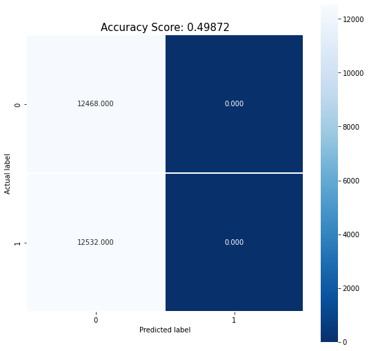

```python
logisticRegr = LogisticRegression()
logisticRegr.fit(ind_train, dep_train)
predicted = logisticRegr.predict(ind_test)
print(classification_report(dep_test, predicted))

score = logisticRegr.score(ind_test, dep_test)
cm = met.confusion_matrix(dep_test, predicted)
plt.figure(figsize=(9,9))
sns.heatmap(cm, annot=True, fmt=".3f", linewidths=.5, square = True, cmap = 'Blues_r');
plt.ylabel('Actual label');
plt.xlabel('Predicted label');
all_sample_title = 'Accuracy Score: {0}'.format(score)
plt.title(all_sample_title, size = 15);
```

Finally, I tested a logistic regression model on my data. Logistic regressions use the independent variables to classify the data into binary outcomes. This seemed to be ideal for my data as I only have two categories. However, the performance was underwhelming. With an accuracy of 0.5, the model was essentially a coin toss and performed much worse than the previous algorithms.

# Conclusion and Further Exploration

From the preliminary analysis of song attributes between the top 200 and viral 50, it seemed that the differences were so negligible between the playlists that classification would be futile. However, machine learning has proved itself yet again by demonstrating the ability to classify songs, based on their auditory attributes, with almost 70% accuracy. Random forest classification being the standout algorithm. Its accuracy would have surely increased if provided with more data. Unfortunately, due to resource constraints, scraping data was an extremely time expensive task. I would like to see this experiment repeated with much larger datasets. For now, I believe this is a fascinating insight into machine learning. It would seem intuitive to us that viral songs would be essentially the same as the most popular songs. However, machine learning has proven that songs do have auditory attributes that contribute to their popularity and virality. Perhaps a song’s “instrumentalness” is such an attribute with our preliminary graphs showing it to be the main difference between a viral song and a popular one. If the differences between instrumentalness were minimized, would machine learning algorithms still be effective for this problem?